# Uvod u jezik R

R je programski jezik i okruženje za statističke izračune i vizualizaciju. R je slobodan programski jezik (engl. free) što znači da se može slobodno koristiti i distribuirati te da je otvorenog kôda (engl. *open-source*). Izraz “okruženje” ističe da je R dobro planiran i konzistentan sustav, a ne sustav koji se postepeno dopunjava specifičnim i nefleksibilnim programskim alatima, što je često slučaj kod drugih programa za analizu podataka.

Program R pruža širok izbor statističkih metoda za linearno i nelinearno modeliranje, klasične statističke testove, analize vremenskih serija, klasteriranje. Lako je proširiv s velikim izborom grafičkih tehnika.

R je implementacija jezika S kojeg je razvio John Chambers s kolegama u Bell Laboratories te Robert Gentleman sa sveučilišta u Aucklandu, Novi Zeland. Ista grupa razvila je i jezik C i UNIX. Trenutno jezik R razvija tzv. *jezgra*, osnovna grupa za razvoj jezika R (engl. *R Core Team*). Postoje neke važne razlike, ali mnogi programi (kôd) napisani u jeziku S rade nepromijenjeni i u jeziku R.

R je proizvod aktivnog pokreta među statističarima koji ima cilj stvaranje moćnog, programibilnog, prijenosnog, otvorenog računalnog okruženja primjenjivog pri rješavanju večine kompleksnih problema, ali i provedbi rutinskih analiza.

Statističari su razvili stotine specijaliziranih statističkih procedura za širok raspon uporabe putem tzv. pridodanih paketa (engl. *contributed packages*) koji su slobodno dostupni i integrirani direktno sa sustavom R. Donedavno je postojalo uvriježeno mišljenje da sustav R koristi uglavnom akademska zajednica dok je za analize podataka u tvrtkama standard sustav SAS. No to se danas promijenilo. Sustav R je npr. Federalna agencija za lijekove (Federal Drug Administration - FDA) identificirala je dijelove R-a pogodnim za tumačenje podataka iz kliničkih istraživanja.

Također, velik je broj kompanija koje prelaze na sustav R za analizu i prezentaciju svojih podataka. Neke od njih nalaze se na popisu koji se može pronaći na sljedećoj poveznici:http://www.listendata.com/2016/12/companies-using-r.html.

Usmjeravanje baza podataka tvrtke ORACLE na povezivanje sa sustavom R (https://blogs.oracle.com/R/entry/announcing_oracle_r_enterprise_1) (http://www.oracle.com/technetwork/topics/bigdata/r-offerings-1566363.html) te prvi puta stavljanje sustava R na Gartnerov magični kvadrant uvjerilo je i najveće skeptike u vjerodostojnost sustava R kao relevantnog sustava za analitiku velikih skupova podataka, naprednu analitiku i vizualizaciju

Kusum i Legović (2004) navode značajnu razliku u filozofiji između sustava SAS i R: u sustavu S (R) statistička se analiza obično provodi u nizu koraka pohranjujući međurezultate pojedinih koraka u objekte. Na primjer, neki poznatiji komercijalni paketi kao što su SAS i SPSS će dati obilne rezultate iz regresijske ili diskriminantne analize dok će sustav R dati minimalan rezultat i pohraniti rezultate u odgovarajuće objekte za kasnija ispitivanja drugim funkcijama sustava R.

## Neke prednosti sustava R

Neke od prednosti sustava R su:

R je dostupan kao slobodan softver pod uvjetima Free Software Foundation GNU Opće javne licence u obliku izvornog kôda (http://en.wikipedia.org/wiki/GNU_Project):

- Sloboda uporabe programa u bilo koje svrhe - sloboda 0
- Sloboda proučavanja načina rada programa i mogućnost prilagodbe vlastitim potrebama - sloboda 1
- Sloboda kopiranja i distribucije programa - preduvjet za to je slobodan kôd (engl. *free-source*) sloboda 2
- Sloboda poboljšavanja programa i mogućnost dijeljenja poboljšanog programa u zajednici - sloboda 3
- Dostupan je putem Interneta
- Radi na raznim platformama UNIX i sličnim sustavima (uključujući FreeBSD i Linux), Windows i MacOS
- Proizvod je međunarodne suradnje vrhunskih statističara i dizajnera programskih jezika
- Dozvoljava statističke analize i vizualizaciju te njihovo neograničeno unaprjeđenje
- Ima mogućnost rada na velikim i kompleksnim objektima - ograničenja su vezana uz operacijski sustav koji koristimo, a ne sustav R.
- Postoji vrlo dobra tehnička dokumentacija o paketima i njihovim funkcijama te velik broj udžbenika i priručnika (https://cran.r-project.org/manuals.html) koje, između ostalih, pripremaju sami korisnici. Također, postoji i velik broj knjiga koje objašnjavaju kako provesti pojedine vrste analiza koristeći sustav R. Poveznica na glavnu dokumentacijsku stranicu sustava je https://www.r-project.org/other-docs.html.
- Svaki korak u analizi je sačuvan i takva povijest (*.Rhistory* datoteka) može se naknadno koristiti u novim analizama ili kao dokumentacija postojećoj.
- Radi svoje organizacije potiče kritičko razmišljanje tijekom provedbe analize, za razliku od čestog poticanja izvršavanja analiza pritiskom na jednu tipku.
- U potpunosti je programibilan i u podlozi nosi vrlo sofisticiran jezik S.
- Pisanjem skripti i korisničkih funkcija analize se jednostavno automatiziraju. Na taj način je i pojednostavljena priprema korisničkih paketa i njihovo stavljanje zajednici na uporabu i provjeru.
- Programski kôd svake funkcije je javan i vidljiv je svaki korišteni algoritam. Uz to, stručnjaci - statističari osiguravaju korektnost ponuđenih funkcija.

## Neki nedostaci sustava R

Veoma se često navode neki od nedostataka sustava R kao što su:

-R nije jednostavan za početnike i nemali broj osoba koje susame započinjale edukaciju su u tome odustale. Ipak, nakon početnog usvajanja znanja o osnovnom načinu funkcioniranja sustava i strukturama podataka, linija učenja je za R veoma strma i slične je ostalim statističkim paketima.

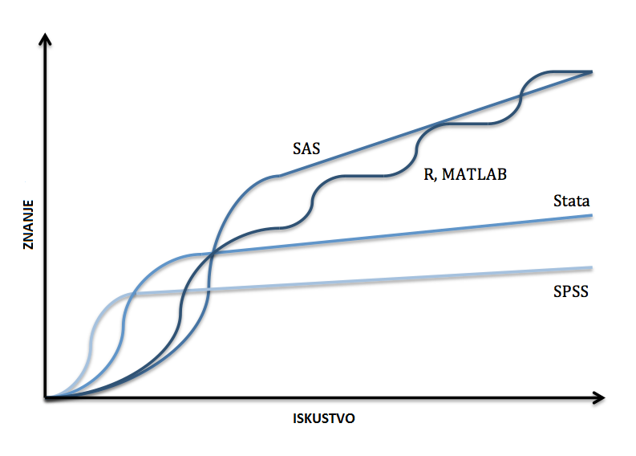

Krivulja učenja najčešćih statističkih programa i paketa; izvor: https://sites.google.com/a/nyu.edu/statistical-software-guide/summary

- U svojoj suštini temelji se na 40 godina staroj tehnologiji
- Postoji slaba podrška analizama putem grafičkih sučelja (engl. *Graphical User Interface - GUI*). Za rad u R-u ulavnom je nužno je pisanje naredbi kako bi se provele analize i napravila vizualizacija rezultata. Mnogi korisnici ovo ne smatraju nedostatkom radi uspostave potpune kontrole nad sustavom. Ipak, noviji projekti rjašavaju i problem korisnika koji ne žele učiti R sintaksu preporučamo upoznavanje s projektom Deducer (http://www.deducer.org/pmwiki/index.php?n=Main.DeducerManual?from=Main.HomePage). Od starijih rješenja postoji paket *Rcmdr* koji u određenoj mjeri omogučava način rada GUI i određen skup analiza
- Korisnik odlučuje o svakom koraku analize i provodi je po koracima. Ovakav način rada omogućuje prednosti kao što je čuvanje tijeka analize (engl. *processing log*) koji se koristi u svrhu izvještavanja ili ponavljanja analize. Mnogi navedeno smatraju prednošću.
- Korisnik treba prihvatiti novi način razmišljanja o podacima koje analizira, te o objektima i metodama. Mnogi ovo smatraju prednošću jer klasa objekta određuje koje metode ima smisla primijeniti
- U velikom broju slučajeva korisnik treba učiti jezik S/R kako bi bio u mogućnosti specificirati analizu, iako danas postoji velik broj projekta i tvrtki koje nude različite oblike podrške korisnicima sustava R (npr. bivši Revolution Analitics, sada Microsoft) ili mogućnost on-line analize u oblaku (engl. *cloud*), kao npr. StatAce.

## Instalacija sustava R

Kako je već spomenuto, R je sustav koji radi na različitim platformama, kao što su UNIX, Windows, Mac OS te njihovim operacijskim sustavima. Prilikom instalacije programskog okruženja treba pronaći odgovarajući kôd te pratiti upute o instalaciji. S web-stranice http://cran.r-project.org/bin/ potrebno je odabrati verziju kompatibilnu operacijskom sustavu na računalu. Instalacija na operacijski sustav Windows je klasična i ovom prilikom nećemo je detaljnije opisivati.

Napomenut ćemo da velik broj istraživača priprema i vlastite pakete koji su dostupni jedino putem njihovih osobnih Github spremišta.

### Programski paketi koji dolaze s instalacijom sustava R

Određene osnovne funkcionalnosti sustava R dobivaju se sa sustavom instalacijom. To su tzv. osnovni paketi koji podržavaju programski jezik S, osnovnu statistiku i osnovnu (oznaka prioritea - engl. *priority* **base**) grafiku. Neki od paketa uključeni su u instalaciju sustava R su: *base*, *compiler*, *datasets*, *graphics*, *grDevices*, *grid*, *methods*, *parallel*, *splines*, *stats*, *stats4*, *tcltk* i *utils*. Ovaj skup paketa ne mijenja se između dvije verzije sustava R i svi nose oznaku temeljnih paketa (priority=“base”). Pakete iz ove grupe nije moguće pronaći neovisne na spremištu CRAN. Drugi skup paketa sustava je dio i same instalacije sustava R, ali se njihove verzije mogu nadograđivati između pojedinih verzija i kao takvi se mogu i pojedinačno pronaći na spremištu CRAN (oznaka prioritea - engl. *priority* **recomended**). Neki od njih su *KernSmooth*, *MASS*, *Matrix*, *boot*, *class*, *cluster*, *codetools*, *foreign*, *lattice*, *mgcv*, *nlme*, *nnet*, *rpart*, *spatial*, *survival*.

Paket base (library (*base*)) čini okosnicu sustava R sadržavajući osnovne funkcije: aritmetika, ulaz i izlaz podataka, osnovne programske potpore, itd. Nešto kasnije upoznat ćemo se detaljnije s nekim od funkcija paketa base. Radi lakšeg snalaženja, mnogobrojni paketi dostupni unutar spremišta CRAN grupirani su u manji broj tzv. spaktara aplikacija (engl. *Task Views*), čiji se popis se može pronaći na stranici http://cran.r-project.org/web/views.

### Nadogradanja sustava R kontribuiranim paketima

Mogućnosti jezika R proširene su putem paketa koje razvijaju korisnici i time omogućuju uporabu specijaliziranih statističkih tehnika, grafičkih uređaja, uvoz/izvoz s preko 11000 dodatnih paketa (stanje srpanj 2017.) dostupno je na sveobuhvatnoj arhivi sustava R (CRAN: The comprehensive R Archive Network), Bioconductor (repozitorij paketa za analizu genomskih podataka) i drugim spremištima (engl. *repository*). Budući se svi paketi neophodni za praćenje ovog tečaja nalaze na spremištu CRAN, ovaj će se izraz u daljnjem tekstu odnositi upravo na ovo spremište.

Da bi se neki paket mogao staviti na CRAN spremište neophodno je da zadovolji konzistentnost rada na različitim operacijskim sustavima, prođe provjeru korektnosti zapisa o potrebama provjera paketa na kojima se ovaj paket temelji (engl. *dependency*), provjere inverzne ovisnosti o neštetnosti paketa na već postojeće (engl. *reverse dependency*) te da ima pripremljenu obaveznu dokumentaciju o funkcionalnostima koje paket nudi, tzv. referentni priručnik (engl. *reference manual*). Svaki paket koji je prošao provjere i pohranjen je na spremištu CRAN ima svoju web stranicu. Upoznat ćemo se s izgledom stranice nekog paketa na primjeru paketa *akima*. Iako je moguće zatražiti informacije iz sustava, ovaj puta ćemo u web pretraživač unijeti upit, primjerice “package akima in r”. Tražilice će nam na ovako postavljen upit redovno kao prvu poveznicu nuditi web stranicu formata (za paket *akima*) https://cran.r-project.org/web/packages/akima/index.html. Upoznajmo se sa strukturom stranice te informacijama koje pruža.

Jednako vrijedi i za sve ostale pakete na spremištu.

Mogućnosti sustava možemo nadograditi instalacijom dodatnih paketa funkcija te unošenjem njihovih funkcionalnosti u sustav. To radimo u sljedećih nekoliko koraka:

#### Izbor repozitorija (spremišta) paketa

Naredbom *setRepositories()* odabiremo na kojim spremištima paketa želimo pretraživati funkcionalnosti. Do istog dijaloga može se doći putem padajućeg izbornika na konzoli sustava R Packages -> Select repositories.

```r
setRepositories()
```

Uz pomoć naredbe *chooseCRANmirror()* možemo izabrati željenu zrcalnu stranicu spremišta CRAN. Uz pomoć naredbe *getCRANmirrors()* možemo doći do informacija gdje se sve nalaze zrcalne stranice spremišta CRAN. Ova funkcija bila je znatno važnija u ranijim vremenima znatno sporijeg prometa podataka na internetu.

```r
chooseCRANmirror()
```

Izabrana opcija ostat će aktivna do trenutka izlaska iz sustava R.

**Napomena:**

```r
chooseCRANmirror()
```

Na konzoli će se ispisati sintaksa. Ako želite provesti naredbu sa zadanim vrijednostima tada treba upisati naredbu te potom znakove *()*. Ako za traženu funkciju ne postoje zadane (engl. *default*) vrijednosti na konzoli će se pojaviti poruka koja nas o tome obavještava. Ukoliko želite vidjeti sam kôd neke funkcije tada naziv funkcije upisete u R konzolu bez otvaranja zagrada i unosa argumeneta. Na ovaj način, ranije pripremljene funkcije unutar sustava korisnik može ili koristiti ili na željeni način dodatno prilagoditi svojim potrebama bez kretanja od nule.

#### Instalacija paketa sa spremišta (engl. *repository*)

Instalacija paketa s nekod od spremišta/repozitorija paketa radi sef unkcijom *install.packages()*, a kao argument unijeti pod navodnicima ime paketa. Upoznajte se s funkcijom te instalirajte paket *ggplot2*.

```r
?install.packages
```

```r
install.packages("ggplot2")
```

Sama instalacija paketa ne čini funkcije paketa dostupnima. Svaki puta prilikom početka rada u sustavu potrebno je učitati u radni prostor funkcije željenog paketa funkcijom *library()* ili *require()* pri čemu funkcija *library()* učitava funkcionalnost instaliranog paketa, dok funkcija *require()* prethodno provjeri da li su funkcionalnosti paketa već unesene u radnu konzolu te tek prema potrebi učita njegova funkcionalnost.

```r
library("ggplot2")
```

Ukoliko želimo instalirali sve pakete koje su dostupni u željenom spektru aplikacija (engl. *Task View*) najprije je potrebno instalirati paket ctv funkcijom *install.packages()*. Ipak, kao i u svakom slučaju kada želimo koristiti neku funkciju unutar sustava, nema potrebe za učenjem sintakse već se najprije treba upoznati sa sintaksom željene funkcije, otvaranjem njezine informacijske kartice pa tek onda njezinom upotrebom.

```r
install.packages("ctv")
```

```r
library("ctv")
```

Tek tada su funkcionalnosti paketa ctv u sustavu, u mogućnosti smo sve pakete iz nekog željenog spektra zadataka odjednom unijeti u svoj sustav.

Ovo je primjer za spektar zadataka vezanih za analize multivarijantnih podataka

```r
install.views("Multivariate")
```

ili

```r
update.views("Multivariate")
```

#### Instalacija paketa putem lokalne datoteke

Paketi se mogu instalirati iako još nisu provjereni i postavljeni na nekim od spremišta, iz lokalne datoteke (engl. *installing from source*), tj. istom naredbom install.packages(), ali dajući argumente *repos*=NULL, *type*=“source”.

```r
install.packages("ime_paketa", repos=NULL, type="source")
```

gdje je datoteka formata tar.gz ili

```r
install.packages("rgdal_0.9-1.zip", repos = NULL, type ="source")
```

gdje je datoteka formata zip.

Ili sljedećim kôdom na primjeru paketa gdal

```r
download.file("http://cran.r-project.org/src/contrib/Archive/rgdal/",
              "rgdal_0.9-1.tar.gz")
list.files(getwd(), pattern="gz")
system("R CMD INSTALL rgdal_0.9-1.tar.gz")
```

#### Instalacija paketa s osobnih Git/GitHub spremišta

U posljednjih nekoliko godina, postoji trend pohrane pripremljenih fukcija i cjelovitih paketa na osobnim GitHub repozitorijima. Za razliku od paketa pohranjenih na repozitorijima poput CRAN-a, gdje je referentni priručnik obavezna dokumentacija paketa koja nam kasnije omogućava traženje informacije o pojedinoj funkciji (otvaranje infrmacijske kartize funkcije), na GitHub repozitorijima pojedinih programera/statističara ovakvu konzistentnu dokumentaciju možda nećemo pronaći. Ipak, najčešće se neki oblik dokumentacije paketa nalazi u datotekama indikativnih naziva, primjerice *readme.txt* ili slično. Ovakav pohrana paketa događa se najčešće unutar područja veoma intenzivnog razvoja i želje autora da zajednici ponude svoja programska rješenja i prije no što uspiju zadovoljiti sve zahtjeve spremišta. Velika večina paketa koje je zajednica prihvatila i počela koristiti u konačnici dospiju i na spremište poput CRAN-a ali GitHub ostaje mjesto pohrane, posebno verzija u izradi ii fazi testiranja. Ukoliko želite instalirati neki od paketa pohranjenih na GitHub repozitorijima programera, najprije je unutar sustava R potrebno instalirati paket *devtools*.

Primjer instalacije paketa *sf* za rad s prostornim bazama podataka s Git spremišta naziva r-spatial:

```r
library(devtools)
install_github("r-spatial/sf")
```

## Informacije o paketima i funkcijama

R je sustav u kojem je traženje pomoći veoma važno radi količine dostupnih funkcionalnosti. Kao što je već spomenuto, funkcionalnosti nekih paketa uneseni su u sustav samom instalacijom sustava R. Takav je paket *utils* koji u sebi nosi ugrađene funkcije za traženje pomoći kao što funkcije s kojima ćemo s upoznati.

### Pretraživanje lokalno instaliranog sustava (engl. *offline*)

Osnovnu stranicu za pomoć možemo pozvati na način, generalna pomoć u radu:

```r
help.start()
```

Kao i kod svake druge funkcije, možemo pogledati njezinu dokumentaciju kako bismo bili sigurni što nam omogućava.

```r
?help.start
```

Kako bi dobili uvid u sve funkcije koje sadrži neki paket dovoljno je napisati ovu naredbu:

```r
library(help = "base") #pomoć za paket base
```

Po unosu naredbe [Enter] otvorit će nam se informacijska kartica za traženi paket. Primjer za pomoć oko paketa base:

```r
#help(ime_paketa)
help(base)
```

ili najjednostavnije

```r
?ime_paketa
```

što nam daje informaciju o pravilnoj sintaksi za traženje informacije o funkcionalnostima nekog paketa.

Potpuni popis funkcionalnosti nekog paketa dobit ćemo sljedećim kôdom:

```r
library(help = "base")
```

Funkcija *help()* može se zamijeniti upitnikom *?* (funkcija *Question* iz paketa **utils**). Funkcija *Question()* omogućava pristup dokumentaciji. U primjeru koji slijedi funkcijom *Question* iz paketa *base* tražimo informacije o samom paketu *base*.

```r
?base
```

Pomoć pri uporabi funkcije npr. *read.table()*:

```r
help(read.table)
#jednako kao i sljedeće
?read.table
```

Prikaz primjera upotrebe funkcije *as.matrix()*:

```r
example(as.matrix)
```

Samostalno proučite promjer korištenja funkcije *read.table()*.

Funkcija *help.search()* omogućuje pretraživanje u instaliranom sustavu dokumentacije podudaranjem određenog niza znakova u imenu datoteke, pseudonimu, naslovu, konceptu ili ključnim riječima (ili bilo koje njihove kombinacije).

Isprobajte slična pretraživanja i za druge pojmove s kojima ste se susreli u svojem dosadašnjam radu.

```r
help.search("logistic")
```

jednako kao

```r
??logistic
```

Iako veoma korisna i često korištena, funkcija *help()* i operator *?* korisni su ukoliko poznajemo ime funkcije koju tražimo. Unutar sustava R postoje funkcionalnosti koje nam omogućuju da, iako ne znamo ime željene funkcije i objekte kao što je funkcija *apropos()*. Popisi svih funkcija i objekata koje u sebi imaju riječ “raster”:

```r
#pretražujemo sve objekte (time i funkcije) na putu pretraživanja
apropos("raster")
```

### Pretraživanje globalnog sustava (engl. *online*)

Pretraživanje dokumentacije koja postoji na cjelokupnom webu, pretražujući obaveznu dokumentaciju (engl. *reference manuals*) i opcionalnu dokumentaciju (engl. *vignettes*) za pakete koji se nalaze na repozitoriju CRAN. Za razliku od funkcija *apropos()* i *help.search()* funkcija zahtjeva vezu prema internetu te pretražuje globalni sustav pomoći.

```r
RSiteSearch("principal component analysis")
RSiteSearch("krige dimensions do not match")
```

```r
RSiteSearch("logistic regression")
```

#### Traženje dokumentacije o instaliranim paketima

Osnovna stranica za traženje dokumentacije o uporabi sustava R i njegovih paketa u specifičnim analizama je http://www.r-project.org/other-docs.html.

##### Obavezna dokumentacija paketa na CRAN-u

Svaki paket na repozitoriju CRAN mora sadržavati i osnovnu dokumentaciju o funkcionalnostima (http://cran.r-project.org/web/packages/ime_paketa/index.html) koje nazivamo (engl. *reference manual*) s popisom svih funkcija i njihovih argumenata. Direktno iz sustava moramo tražiti *help(package=ime_paketa)*.

##### Opcionalna dokumentacija paketa na CRAN-u

Vinjete su opcionalni dokumenti vezani za određeni korisnički paket. U njima su opisane funkcionalnosti paketa na nekom specifičnom problemu. One prižaju priču o tome što se s paketom može napraviti i ne rade ih nužno autori funkcija već vinjete ponekad napišu iskusni korisnici funkcionalnosti paketa. Prikaz svih dostupnih vinjeta instaliranih paketa možemo vidjeti ako unesemo sljedeće:

```r
vignette()
```

Ukoliko želimo vinjete unutar određenog paketa:

```r
#upoznavanje sa sintaksom funkcije
?vignette
vignette(package="ime_paketa")
#otvaramo vinjetu za koju znamo točan naziv
vignette("ime_vinjete")
```

Ukoliko želimo vidjeti popis svih vinjeta za sve učitane (engl *attached*) pakete:

```r
vignette(all=FALSE)
```

Ukoliko želimo vidjeti popis svih vinjeta svih paketa koje imamo na instalirane na računalu:

```r
vignette(all=TRUE)
```

**ZA SAMOSTALAN RAD**:

Potražite vinjete paketa *sp* i paketa *akima* te prokomentirajte razliku. Ukoliko već nisu, instalirajte navedene pakete.

Funkcijom *browseVignettes()* otvaramo web-stranicu s vinjetama svih paketa koji su instalirani na našem sustavu ili samo određenog paketa kojeg smo definirali u naredbi. Vinjete je moguće preuzeti u formatima PDF, R i Latex.

```r
browseVignettes (package="sp")
```

Osnovna stranica na kojoj je moguće pronaći ogroman broj priručnika s većeg broja spremišta paketa nalazi se na poveznici https://www.rdocumentation.org/ dok se snovna stranica s priručnicima o R jeziku i paketima pohranjenim na CRAN-unalazi se na poveznici https://cran.r-project.org/manuals.html.

#### Komunikacijske liste u sustavu R

Unutar sustava R postoje četiri glavne komunikacijske liste (engl. *Mailing Lists*) na kojima se nalaze informacije o sustavu:

- R-announce (https://stat.ethz.ch/mailman/listinfo/r-announce)

Na ovoj se listi objavljuju velike novosti u sustavu kao što je izdavanje nove verzije sustava R i promjene koje donosi.

- R-packages (https://stat.ethz.ch/mailman/listinfo/r-packages)

Ovdje se objavljuju novosti o nadogradnji postojećih i dostupnosti novih paketa - uglavnom se odnosi na spremište CRAN.

- R-help (https://stat.ethz.ch/mailman/listinfo/r-help)

Ovo je glavna obavijesna lista za sustav R, a namijenjena je raspravi o problemima i rješenjima pomoću sustava R, najavama koje nisu objavljene na prethodne dvije liste, obavijestima o dokumentaciji za sustav R, usporedbi i kompatibilnosti s jezikom S-plus te širenju dobrih primjera. R-announce i R-packages prosljeđuju sve obavijesti na R-help.

- R-devel (https://stat.ethz.ch/mailman/listinfo/r-devel)

Ova je lista namijenjena pitanjima i raspravi vezanima za razvoj kôda programskog jezika R.

#### Grupe specijalnog interesa

Unutar sustava došlo je do stvaranja zajednica korisnika sustava R s posebnim interesima (engl. *Special Interest Group* - SIG). Tako je moguće predbilježiti se za primanje obavijesti vezanih uz određeno područje, na primjer, u našem je to slučaju grupa koja koristi i razvija alate za analize prostornih podataka R-SIG-geo na mrežnim stranicama.

Ukoliko ste početnik i ne razumijete poruke koje Vam sustav javlja kao pogrešku, najbolji i najjednostavniji način je kopiranje teksta pogreške i unošenje u internetski pretraživač (na primjer Google). Na isti način moguće je pronaći i velik broj dokumenata i znanstvenih radova s temom koja nas zanima.

Ako na opisane načine niste uspjeli riješiti svoj problem i odlučite postaviti pitanje na neku od distribucijskih lista važno je:

- dati primjer koji će drugi korisnici moći reproducirati
- navesti koji ste rezultat očekivali, odnosno pokušali dobiti
- navesti što je prikazano umjesto očekivanog rezultata
- navesti verziju sustava R i paketa korištenih u analizi
- navesti naziv i inačicu operacijskog sustava kojeg koristite
- osmisliti naslov poruke koji će na jasan način predstaviti problem.

#### Specijalizirane konferencije

Informacije o konferencijama o sustavu R mogu se pronaći na poveznici http://www.r-project.org/conferences.html. R-projekt aktivno podupire rad dva tipa konferencija koje redovno organizira R-zajednica:

- **useR!**

  konferencija-forum korisnika sustava R i
- **DSC (*engl. Directions in Statistical Computing*)**

  konferencija koja okuplja programere statističkog softvera i istraživača u statističkom računalstvu koji su usredotočeni na sustav R, ali nije isključivo posvećena sustavu R. Cilj konferencije je osigurati platformu za razmjenu ideja o zbivanjima u statističkom računalstvu.

#### Ostala literatura o sustavu R

Unutar sustava R postoji velika količina literature slobodno dostupne korisnicima. Osnovna grupa suradnika za razvoj sustava R (*engl. R Core Team*) zadužena je za održavanje i sadržaj mrežnih stranica s priručnicima.

Za operacijski sustav Windows literatura je dostupna putem poveznice http://cran.r-project.org/manuals.html. Putem ovih stranica moguće je doći do priručnika prevedenih na druge svjetske jezike (http://cran.r-project.org/other-docs.html).

Osim literature unutar sustava pomoći navodimo još neke od klasičnih tekstova koji olakšavaju početak rada u sustavu R:

- Chambers (2008) Software for data analysis, Springer
- Chambers (1998) Programming with data, Springer
- Venables & Ripley (2002) Modern Applied Statistics with S, Springer
- Venables & Ripley (2000) S Programming, Springer
- Pinheiro & Bates (2000) Mixed-Effect Models in S and S-PLUS, Springer
- Murrel (2005) R Graphics, Chapman & Hall / CRC Press
- Use R! Serija knjiga, Springer
- Serija knjiga izdavača Wiley
- …
- The R Journal

[figure not shown]

Knjige o sustavu R iz različitih izvora

*Open-access* časopis koji objavljuje kraće članke vezane uz projekt razvoja softvera u sustavu R koji bi mogli biti od interesa kako osobama koji sustav razvijaju tako i korisnicima, a može se pronaći na: http://journal.r-project.org/current.html.

Velik broj kniga o sustavu R moguće je pronaći na poveznici : http://www.r-project.org/doc/bib/R-books.html ali s naznakom da lista nije u potpunosti ažurirana.

Na hrvatskom jeziku, osim tečajeva Srca, moguće je pronaći relativno stare, dokumente:

*Uvod u korištenje R-a* (2004) Damir Kasum i Tarzan Legovic s Instituta Ruđer Bošković preveli su knjigu *An introduction to R* autorskog tima W.N. Venables, D.M. Smith i osnovna grupa suradnika za razvoj sustava R (http://cran.r-project.org/doc/contrib/Kasum+Legovic-UvodUr.pdf).

*Osnovne naredbe u R-u* Damir Kasum (http://cran.r-project.org/doc/contrib/Kasum-QuickRefCard_ver.1.2.pdf).

### Određivanje okoline za rad

Posao je okoline povezivanje skupa sa skupom vrijednosti. Naredbom *search()* bez dodatnih argumenata dobit ćemo popis redosljeda spajanja vrijednosti u radnom prostoru. Ujedno iz njega vidimo i popis svih paketa učitanih u radnu okolinu kao i redoljed njihova učitavanja.

```r
search()
```

```
## [1] ".GlobalEnv"        "package:stats"     "package:graphics"
## [4] "package:grDevices" "package:utils"     "package:datasets"
## [7] "package:methods"   "Autoloads"         "package:base"
```

Naredbom *library()* bez dodatnih argumenata dobit ćemo popis svih instaliranih paketa u našem sustavu.

### Skupovi podataka za vježbu

Unutar R sustava postoji određen broj skupova podataka na kojima možete isprobavati funkcije i pripremati analize. Velik broj skupova podata sakupljeno je i dostupno putem paketa *datasets* koji dolazi instalacijom sustava i obuhvaća raznolike strukture podataka s kojima možete vježbati.

```r
#skupovi podataka za vježbu unutar paketa "datasets"
data()
```

Ipak, paket *datasets* ne sadži podatke organizirana u specijalizirane interne R klase za specifične analitičke metode kao što su geografski referencirani podaci, prostorno vremenski podaci te mnogi drugi primjeri koje velik broj korisnika nikada i neće susresti u svojem radu. Ukoliko je potrebno za razumijevanje funkcionalnosti koje neki specifičan paket nudi, autori paketa, često u sklopu paketa dostavljaju adekvatne podatke na kojima je moguća vježba i upoznavanje s funkcionalnostima.

Prokomentirajte razliku između paketa raster i sp. Ukoliko je potrebno, napravite i instalaciju ova dva pekate te njihove funkcionalnosti učitajte u radni prostor funkcijama *library()* ili *require.

```r
#install.packages("raster")
#install.packages('sp')
data(package = "raster")
data(package = "sp")
```

### Prijelaz na novu verziju sustava R

Najjednostavniji način prelaska na novu verziju sustava R je kopiranje i prebacivanje svih instaliranih paketa iz mape

```r
...\\R\\R-ver1\\library
```

u mapu paketa verzije 2

```r
...\\R\R-ver2\library
```

Na staroj verziji sustava R napravite sljedeće, uporabom primjera s verzijom R-3.4.1:

```r
setwd("../S720")
packages <- installed.packages()[,"Package"]
save(packages, file="Rpackages")
#Na novoj verziji sustava R napravite sljedeće:
setwd("..C:/Temp/")
load("Rpackages")
for (p in setdiff(packages, installed.packages()[,"Package"]))
install.packages(p)
```

Kako je sustav R izuzetno fleksibilno okruženje, gotovo u svakoj prilici postoji mnogo načina na koje se može doći do željenog rezultata. Da bismo potkrijepili ovu tvrdnju isto ćemo napraviti putem već pripremljenog paketa *installr*; instaliranje i učitavanje najnovije verzije *installr* paketa.

```r
install.packages("installr")
library(installr)
updateR()
```

Kako bismo bili sigurni da u svojem radu koristite najnoviju verziju nekog paketa moguće je napraviti ažuriranje uporabom naredbe *update.packages()*.

```r
update.packages(checkBuilt=TRUE, ask=FALSE)
updateR()
```

Radi lakše izrade programa (skripti) i upravljanja kôdom sustava R, tijekom tečaja ćemo koristiti RStudio, integralnu platformu za razvoj *(engl. Integrated Development Environment - IDE)* pripremljenu upravo za sustav R. Ova platforma uključuje razne funkcionalnosti, kao što su automatsko detektiranje grešaka u kôdu (engl. *debug*) i pripremu vlastitih paketa, a integrirana je s dokumentacijom o funkcijama te omogućuje integraciju s alatima za automatsku izradu izvještaja kao što su *Sweave* (integracija s dokumentima programa Latex) i R Markdown (izrada HTML-dokumenata). Relativno noviji paket *rmarkdown* u znatnoj je mjeri olakšao reproducibilnu znanost i izvještavanje integrirajući veći broj softwera. Uz nove funkcionalnosti RStudija koje u RMarkdown dokumentima dopuštsju dijelove različitih programskih jezika doveo je pojam reproducibilnosti na posve novu razinu. Korisnik tako danas u jednom dokuementu ima mogućnost korištenja bilo kojeg programskog jezika u kojem može ili zna riješiti neki problem u jedinstveni dokument (primjerice Tex, Python, R…) kombinirajući njih s pisanjem teksta rada ili izvještaja (engl. *literate programming*).

Ukoliko u svojem radu koristite RStudio prelazak na novu verziju R-a je još jednostavniji. S CRAN repozitorija instalirajte željenu verziju R-a, otvorite RStudio i svi će paketi iz ranijih verzija biti dostupni i u novoj. RStudio će automatski prepoznati novu verziju i raditi s njom. Ukoliko to ne želite, pod opcijama programa namjestite (RStudio - Tools - Global Options - General) namjestite željenu verziju R-a za rad. RStudio, također, omogućava instaliranje i/ili ažuriranje pojedinih paketa interaktivno.

### Početak rada

Program R pokreće se na neki od uobičajenih načina za operacijski sustav Windows:

- dvostrukim klikom lijevom tipkom miša na ikonu na radnoj površini (engl. *Desktop*)
- klikom lijeve tipke miša na ikonu na traci za brzo pokretanje programa (engl. *Quick Launch*)
- upisom R-3.4.1 u prompt prozor sustava Windows.

#### Zadavanje naredbi

Većina akcija koje želite napraviti u sustavu radi se putem unosa naredbi koje obično izgledaju ovako: znak **>** ukazuje na spremnost sustava na prihvat nove naredbe (engl. *prompt*) i sustav R ga automatski stavlja na početak retka. Korisnik nikada ne upisuje znak za spremnost kao dio kôda.

Nakon pisanja naredbe potrebno je pritisnuti tipku [ENTER].

Postoji nekoliko načina da sustavu prenesete naredbe:

- izravan upis naredbe u prompt prozor na opisani način
- kopiranje i lijepljenje naredbe iz nekog drugog dokumenta (pojedini red, dio ili cijeli kôd) pritom treba paziti da se ne kopira znak spremnosti sustava (engl. *prompt*) > ili znak prekida naredbe +
- kopiranje i lijepljenje naredbe iz tekstualne datoteke s kôdom sustava R koji nosi nastavak .R; ovaj oblik datoteka može se otvoriti u tekst editoru ili u editoru kôda kakav je Tinn-R ili RStudio
- pripremiti cjelokupnu skriptu u editoru kôda i poslati je na izvršenje na R konzolu.

Sustav R će prihvatiti naredbu koja ima ispravnu sintaksu. Ako to nije slučaj pojavit će se oznaka kojom sustav traži završetak sintakse u obliku znaka plus +. Ukoliko ne želite završavati naredbu, pritisnite tipku [esc].

Kako je za početnike rad s naredbama ponekad zastrašujući, nekoliko grupa razvija i grafička sučelja za rad o kojima u ovome tečaju neće biti govora. Najčešće rabljeno grafičko sučelje za rad u sustavu R je *R commander* dok primat u radu s web grafičkim sučeljima je Deducer.

Radi preglednosti kôda, od sada ćemo pripremljene programe otvarati u programu RStudiJU. Pokrenite RStudio. Ukratko ćemo se upoznati s izgledom programa.

#### Postavljanje radnog direktorija

Za korisnike operacijskog sustava Windows važno je napomenuti da sustav R ne može koristiti notaciju putanje do određene datoteke na način kako se to radi unutar sustava Windows. Na primjer, sustav R neće moći pročitati

```r
c:\mydocuments\file.txt
```

iz razloga što znak *backslash* prepoznaje kao tzv. engl. *escape character* koji sa sobom nosi alternativno tumačenje sljedećeg znaka u nizu znakova. Iz tog razloga putanje do datoteka moraju se promijeniti na jedan od ova dva načina:

1. ili dvije dvostruke linija unatrag (engl. *backslash*)

2. ili jednostruka linija unaprijed (engl. *forwardslash*)

*“c:/mydocuments/file.txt”*

Prije početka rada potrebno je definirati radni direktorij. Informacija o trenutačnom radnom direktoriju dobiva se na ovaj način:

```r
getwd()
```

Radni direktorij određuje se na sljedeći način:

```r
setwd("putanja/moj_direktorij")
```

#### Neke osnovne funkcije za rad u sustavu:

U nastavku slijedi nekoliko funkcija koje je dobro znati prilikom samog početka rada u R sustavu.

Za ispis svih objekata u radnom prostoru (engl. *workspace*) upišite:

```r
ls()
```

Otvaranje informacijske kartice željene funkcije, primjer za funkciju *lm()*

```r
?lm
```

Snimanje i učitavanje objekta i/ ili cjelokupnog radnog prostora:

```r
save(ime_objekta, file="ime_datoteke.RData")
```

Snimanje liste objekata na tvrdi disk:

```r
save(c(ime_objekta1, ime_objekta2), file="ime_datoteke.RData")
```

Snimanje cjelokupnog radnog prostora (svi objekata aktivne sesije) na tvrdi disk

```r
save.image("ime_datoteke.RData")
```

Učitavanje cjelokupnog radnog prostora:

```r
load("ime_datoteke.RData")
```

Snimanje povijesti (datoteke history) na tvrdi disk:

```r
savehistory(file="ime.Rhistory")
```

Učitavanje povijesti (datoteke history) u radni prostor:

```r
loadhistory(file="ime.Rhistory")
```

**Napomena:**

U konzolu sustava R upisujemo naredbe. Simbol <- je operator pridruživanja. Veoma slično, ipak ne identično, ponaša se i drugi simbol pridruživanja vrijednosti =.

Simbol # predstavlja početak komentara i sve napisano desno, uključujući i sam znak, biti će zanemareno prilikom izvođenja naredbi.

Pprogram otvaramo R dvostrukim klikom lijevom tipkom miša na ikonu na radnoj površini. Kopirati je potrebno sve između znakova prompt > i komentara #.

Ne smeta ako je unesen i komentar - program R će ga zanemariti.

**PITANJA ZA PONAVLJANJE:**

1. Kojom funkcijom određujemo radni direktorij u R-u?
2. Što su to vinjete? Kojom funkcijom ih možete pregledati i otvoriti?
3. Što ćete dobiti ukoliko u konzoli izvršite naredbu *help()* bez zadanih argumenata? Prokomentirajte.
4. Što ćete dobiti ukoliko u konzoli izvršite naredbu *help(sd)* ili *help(base)* s dodanim argumentom? Prokomentirajte.
5. Pomoću funkcije *chooseCRANmirror()* odredite kao željenu stranicu s koje ćete uzimati pakete onu iz Italije.
6. Postoji li stranica CRAN-a u Hrvatskoj?
7. Odredite u sustavu radni direktorij ~/S720/user.
8. Prokomentirajte poruku sustava kada ste zatražili skupove podataka iz paketa base.
9. Kojim znakom možete zamijeniti funkciju *help()*?
10. Kojim znakom možete zamijeniti funkciju *help.search()*?
11. Kojom biste funkcijom snimili cjelokupan radni prostor po završetku rada?
12. Razlikuje li R velika i mala slova?
13. Koja je razlika između lokalnog i globalnog pretraživanja? Navedite primjere funkcija.
14. Koja je razlika između funkcija library i require (ako postoji)?

**ZADACI ZA SAMOSTALNI RAD:**

```r
#ZADATAK 1:Kojom biste funkcijom zatražili informaciju
#o trenutnom radnom direktoriju?

#ZADATAK 2: Definirajte željeni radni direktorij kao direktorij
#u kojemu se nalaze skripte za ovaj tečaj.

#ZADATAK 3: Kreirajte objekt koji ćete nazvati razlika.
#U taj objekt spremite razliku brojeva brojeva 19217 i 19113.
#Što bi se dogodilo da ovu razliku nismo spremili u objekt?

#ZADATAK 4: Kreirajte objekt pod nazivom div.
#Objekt treba biti broj 3384 podijeljeno s 51:

#ZADATAK 5: Instalirajte paket ggplot2 i učitajte ga u radni prostor.
#Ima li ovaj paket vinjete, ako da, koliko?
```